# Machine Learning Project Assignment

Akash Das

27 July 2018

## Summary

A group of enthusiasts who take measurements about themselves regularly to improve their health, to find patterns in their behavior, or because they are tech geeks. One thing that people regularly do is quantify how much of a particular activity they do, but they rarely quantify how well they do it. In this project, your goal will be to use data from accelerometers on the belt, forearm, arm, and dumbell of 6 participants. They were asked to perform barbell lifts correctly and incorrectly in 5 different ways. More information is available from the website here: http://groupware.les.inf.puc-rio.br/har (see the section on the Weight Lifting Exercise Dataset).

Read more: The data for this project come from this source: http://groupware.les.inf.puc-rio.br/har.

**The goal of your project is to predict the manner in which they did the exercise.**This is the “classe” variable in the training set. You may use any of the other variables to predict with.

# Exploratory Data Analysis

1. Load Libraries

```r
setwd("E:/Coursera/git-folder/ML_assgn")
library(caret)
library(rpart)
library(randomForest)
set.seed(12345)
```

```r
# Path of the data.

UrlTrain <- "http://d396qusza40orc.cloudfront.net/predmachlearn/pml-training.csv"
UrlTest  <- "http://d396qusza40orc.cloudfront.net/predmachlearn/pml-testing.csv"

# download the data
training <- read.csv(url(UrlTrain))
testing  <- read.csv(url(UrlTest))

dim(training)
```

```
## [1] 19622   160
```

We have total 160 columns in the data set. Below is some description

- Column 1 to 7 are index *column 8 to 159 contains user data in various form. the variable name includes any of following string to understand the respective sensor “_belt, _arm, _dumbbell, _forearm“.
- Column 160 : classe holds the data for execution type.

```r
str(training[,c(1:10,160)])
```

```
## 'data.frame':    19622 obs. of  11 variables:
##  $ X                   : int  1 2 3 4 5 6 7 8 9 10 ...
##  $ user_name           : Factor w/ 6 levels "adelmo","carlitos",..: 2 2 2 2 2 2 2 2 2 2 ...
##  $ raw_timestamp_part_1: int  1323084231 1323084231 1323084231 1323084232 1323084232 1323084232 1323084232 1323084232 1323084232 1323084232 ...
##  $ raw_timestamp_part_2: int  788290 808298 820366 120339 196328 304277 368296 440390 484323 484434 ...
##  $ cvtd_timestamp      : Factor w/ 20 levels "02/12/2011 13:32",..: 9 9 9 9 9 9 9 9 9 9 ...
##  $ new_window          : Factor w/ 2 levels "no","yes": 1 1 1 1 1 1 1 1 1 1 ...
##  $ num_window          : int  11 11 11 12 12 12 12 12 12 12 ...
##  $ roll_belt           : num  1.41 1.41 1.42 1.48 1.48 1.45 1.42 1.42 1.43 1.45 ...
##  $ pitch_belt          : num  8.07 8.07 8.07 8.05 8.07 8.06 8.09 8.13 8.16 8.17 ...
##  $ yaw_belt            : num  -94.4 -94.4 -94.4 -94.4 -94.4 -94.4 -94.4 -94.4 -94.4 -94.4 ...
##  $ classe              : Factor w/ 5 levels "A","B","C","D",..: 1 1 1 1 1 1 1 1 1 1 ...
```

```r
sensorColumns = grep(pattern = "_belt|_arm|_dumbbell|_forearm", names(training))
# total number of columns holding user data
  length(sensorColumns)
```

```
## [1] 152
```

```r
# Start Column
  head(sensorColumns,1)
```

```
## [1] 8
```

```r
# Last Column
  tail(sensorColumns,1)
```

```
## [1] 159
```

# Data Cleaning.

In the dataset we have lots of variable with lots of NA. Also we can remove initial index variables as well

```r
# remove the index variables
training_Updated <- training[,-(1:7)]

#Remove NA
NZV <- nearZeroVar(training_Updated[,1:152])
training_Updated <- training_Updated[, -NZV]

AllNA    <- sapply(training_Updated, function(x) mean(is.na(x))) > 0.95
training_Updated <- training_Updated[, AllNA==FALSE]

dim(training_Updated)
```

```
## [1] 19622    53
```

```r
training_Updated <- na.omit(training_Updated)
table(complete.cases(training_Updated))
```

```
##
##  TRUE
## 19622
```

```r
table(sapply(training_Updated[1,], class))
```

```
##
##  factor integer numeric
##       1      25      27
```

After data cleaning we have 53 columns now and there is no NA in the data. All variables are numeric or integer except one(Classe).

# Data Preparetion for traning

```r
set.seed(111)
# make a partition in training data set.
inTrain = createDataPartition(training_Updated$classe,p=0.7,list=FALSE)
TrainSet = training_Updated[ inTrain,]
TestSet = training_Updated[ -inTrain,]
dim(TrainSet)
```

```
## [1] 13737    53
```

# Prediction Model Building

Method: Random Forest

```r
set.seed(112)

controlRF <- trainControl(method="cv", number=3, verboseIter=FALSE)
modFitRF <- train(classe ~ ., data=TrainSet, method="rf",trControl=controlRF)
modFitRF$finalModel
```

```
##
## Call:
##  randomForest(x = x, y = y, mtry = param$mtry)
##                Type of random forest: classification
##                      Number of trees: 500
## No. of variables tried at each split: 2
##
##         OOB estimate of  error rate: 0.67%
## Confusion matrix:
##      A    B    C    D    E  class.error
## A 3903    2    1    0    0 0.0007680492
## B   15 2638    5    0    0 0.0075244545
## C    0   20 2372    4    0 0.0100166945
## D    0    0   35 2216    1 0.0159857904
## E    0    0    2    7 2516 0.0035643564
```

```r
#Prediction
PredictRF <- predict(modFitRF,newdata = TestSet)
ConfMatrix<- confusionMatrix(PredictRF,TestSet$classe)
ConfMatrix
```

```
## Confusion Matrix and Statistics
##
##           Reference
## Prediction    A    B    C    D    E
##          A 1672    2    0    0    0
##          B    1 1127    6    0    0
##          C    0   10 1019   23    0
##          D    0    0    1  940    4
##          E    1    0    0    1 1078
##
## Overall Statistics
##
##                Accuracy : 0.9917
##                  95% CI : (0.989, 0.9938)
##     No Information Rate : 0.2845
##     P-Value [Acc > NIR] : < 2.2e-16
##
##                   Kappa : 0.9895
##  Mcnemar's Test P-Value : NA
##
## Statistics by Class:
##
##                      Class: A Class: B Class: C Class: D Class: E
## Sensitivity            0.9988   0.9895   0.9932   0.9751   0.9963
## Specificity            0.9995   0.9985   0.9932   0.9990   0.9996
## Pos Pred Value         0.9988   0.9938   0.9686   0.9947   0.9981
## Neg Pred Value         0.9995   0.9975   0.9986   0.9951   0.9992
## Prevalence             0.2845   0.1935   0.1743   0.1638   0.1839
## Detection Rate         0.2841   0.1915   0.1732   0.1597   0.1832
## Detection Prevalence   0.2845   0.1927   0.1788   0.1606   0.1835
## Balanced Accuracy      0.9992   0.9940   0.9932   0.9870   0.9979
```

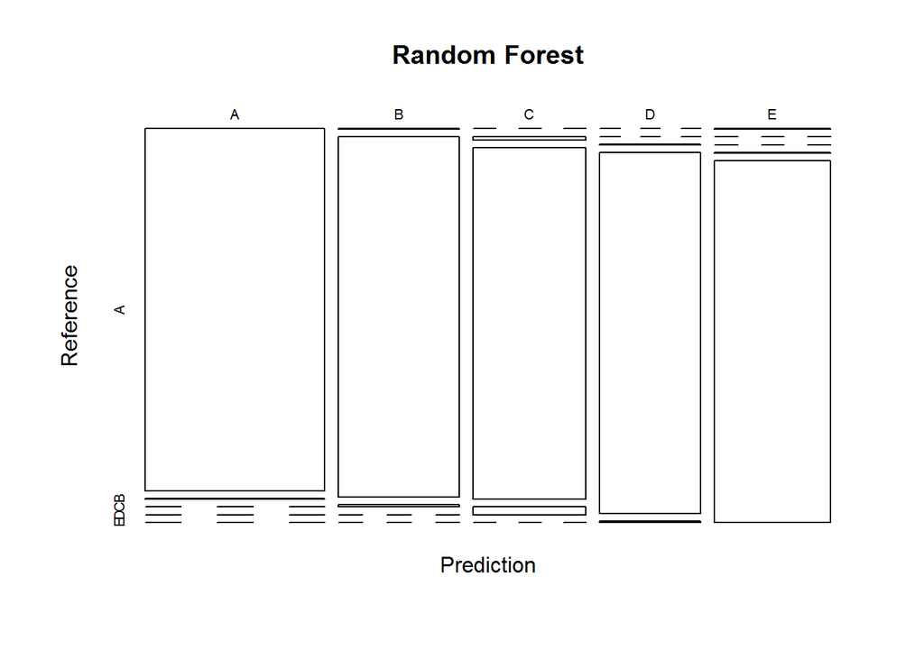

```r
#Plot the result
plot(ConfMatrix$table,col=ConfMatrix$byClass,main = "Random Forest")
```

We have an accurecy of 0.9917 and the Cohen’s kappa indicator of concordance shows the predictor has a low out of sample error rate.

We can check other methods like Decision tree or GBM to check respective accurecy and compare the accuracy to choose best one. However For this assignment We can use this prediction from random Forest for 20 quiz results.

```r
PredictQuiz <- predict(modFitRF, newdata=testing)
PredictQuiz
```

```
##  [1] B A B A A E D B A A B C B A E E A B B B
## Levels: A B C D E
```